# Replication of Study The Curse of Knowledge in Reasoning About False Beliefs by Susan A.J. Birch & Paul Bloom (2007, Psychological Science)

Lauren R. Borchers. Email: lrborchers@stanford.edu

December 13, 2018

## Introduction

In The Curse of Knowledge in Reasoning About False Beliefs, Birch and Bloom investigated how prior knowledge of an outcome can impact bias toward the plausibility of an event (Birch & Bloom, 2007). This study was motivated by prior work conducted by the authors assessing 3 to 4-year-olds’ increased susceptibility toward a cognitive bias, coined the curse of knowledge, compared to 5-year-olds. The authors were interested in investigating whether this bias was also present in older adults. Birch and Bloom specifically wanted to test whether adults would show a deficit in reasoning when they had specific knowledge about the outcome of an event.

This study is relevant to my work in Affective Science because it suggested that knowledge of an outcome can potentially impact perceived likelihood of an event. Given the increasing body of literature indicating that family risk is one of the strongest predictors of depression, I am interested in assessing how likely adolescents with a family history of depression think they will develop the disorder themselves. Further, I want to investigate if adolescents with depression view the severity of their symptoms and length of the episode in accordance with the course of a parents’ depressive episode.

In order to test their hypothesis, Birch and Bloom administered a displacement task given to children with three modifications to make the task more challenging. All participants (N=155, 69 male) were told that a young girl, Vicki, was playing the violin, put her instrument into a blue container, and left the room. Then, they were told that her sister entered the room, moved the violin, and shuffled the containers. Participants were asked to assign the probability that Vicki would look in each container once she reentered the room. There were three manipulations: knowledge-plausible: participants were told the object was moved to a different container but the physical location remained constant; knowledge-implausible: participants were told that the object was moved and the physical location changed; and the ignorance condition: participants were not given any additional information. Birch and Bloom found that participants who were in the knowledge-plausible condition showed this curse of knowledge effect by assigning higher probabilities to the location in which the sister moved the object (same physical location where Vicki left her violin, but different container). Further, the knowledge-plausible condition assigned lower probabilities to the container in which the object was originally placed. The knowledge-implausible and ignorance conditions showed no statistically significant differences. The authors deduced that knowledge was only a “curse” when participants had a reasonable explanation for why Vicki might adjust her beliefs in accordance with the information given.

In my replication study, participants recruited via MTurk will be randomly assigned one of two conditions. I will not be including a knowledge-implausible condition because the authors did not report significant differences between this group and the ignorance condition. Ideally, I will recruit approximately 50% males and 50% females and there will be an even number of participants in each condition. One challenge with this experiment is that participants are asked to write down their probabilities in a text box. Therefore, it is possible that participants will make mathematical errors and that the sum of all containers will not add up to 100%. Further, the original sample solely consisted of college students attending Yale University. Therefore, there will likely be a difference in education between the original group and the sample recruited via MTurk. An additional challenge is that the original study was administered in person and not online so there could be some confounding variables (e.g. visual quality of the stimuli). Finally, while I have access to the figure, it has relatively poor resolution and is black and white with colored labels. I will need to adapt the current image in order to present the stimuli in a similar manner as the original administration.

## Methods

### Planned Sample

I plan to recruit 80 participants (40 per condition). I will ask participants at the beginning of the experiment if they received a high school education or if they are color blind. Participants will be excluded from analyses, but compensated, if they report being color blind or having less than a high school education. Both male and female participants will be included.

### Materials

This study requires a colored figure depicting Vicki, her violin, a sofa, and four containers (ordered: blue, purple, red, green) on the top panel and her sister, the violin, a sofa, and the containers (reordered: red, green, purple, blue) on the bottom panel. All participants were shown the following text (manipulations shown in brackets): “This is Vicki. She finishes playing her violin and puts it in the blue container. Then she goes outside to play. While Vicki is outside playing, her sister, Denise, moves the violin [ignorance] to another container. [knowledge-plausible] to the red container (occupying original location). [knowledge-implausible] to the purple container (not implementing this manipulation, but occupying a random physical space). Then Denise rearranges the containers in the room until the room looks like the picture below. When Vicki returns, she wants to play her violin. What are the chances Vicki will first look for her violin in each of the above containers? Write your answers in percentages in the spaces provided under each container”. All participants will receive the same figure with modifications to the text according to their condition (described above).

### Procedure

This is a between-subjects design and participants will be randomly assigned to the ignorance or knowledge-plausible condition at the beginning of the study. After reading the corresponding prompt, all participants will report on their perceived probability that Vicki will look in each of the four containers for her violin.

### Analysis Plan

I will conduct Independent Samples T-Tests to compare the ignorance and knowledge-plausible conditions’ reported probabilities. Birch and Bloom found that the ignorance condition reported lower probabilities for the red container than the knowledge-plausible condition (where participants in the knowledge-plausible condition were told Vicki’s sister relocated the violin; same physical location as where Vicki originally placed the violin). Further, the knowledge-plausible condition reported lower probabilities for the blue container (where the violin was originally placed by Vicki). The authors did not report on any data cleaning, data exclusion, or covariates.

The main analysis will compare if participants in the ignorance condition report a lower probability that Vicki would look in the red container compared to the knowledge-plausible condition using an Independent Samples T-Test. A follow-up analysis will assess if participants in the knowledge-plausible condition report lower probabilities for the blue container compared to participants in the ignorance condition, also using an Independent Samples T-Test.

### Differences from Original Study

This study will differ from the original study because the sample will be recruited online rather than in person. Further, I will not recruit a knowledge-implausible condition. I currently do not have access to the color version of the figure given to participants. I generated the a colored version myself in powerpoint. It is highly unlikely, but possible that this difference could impact the results. There are no differences in the analysis plan that I am aware of. The main difference between the two studies is the inevitable difference in education. After all, it is highly unlikely that the majority of participants completing the MTurk survey will currently be attending a competitive university. Education likely influences inferences. However, this displacement task was relatively simple and I don’t anticipate educational differences will have a large effect on the outcome.

### Qualtrics code and MTurk requester/worker sandbox test

https://stanforduniversity.qualtrics.com/jfe/form/SV_6WLItFOjhHTkN7f

https:// requestersandbox.mturk.com/manage? openid.pape.max_auth_age=43200&openid.identity=https%3A%2F%2Fwww.amazon.com%2Fap%2Fid%2Famzn1.account.AH7EQKQPZK7MB32SGKY2UCV2DKZA&stashKey=f5d2416f- ca07-40d3- b7f5-96db605e025d&openid.claimed_id=https%3A%2F%2Fwww.amazon.com%2Fap%2Fid%2Famzn1.account.AH7EQKQPZK7MB32SGKY2UCV2DKZA

[https:// workersandbox.mturk.com/projects/3QXBZN23LGZPBXBY73377T4YGMRXN5/tasks/ 3NI0WFPPI9G82M1JN5I9MM9G0GE60C? assignment_id=3Z9WI9EOZZOSYLQYDJOXQH9VW56KH1&auto_accept=true](https://workersandbox.mturk.com/projects/3QXBZN23LGZPBXBY73377T4YGMRXN5/tasks/3NI0WFPPI9G82M1JN5I9MM9G0GE60C?assignment_id=3Z9WI9EOZZOSYLQYDJOXQH9VW56KH1&auto_accept=true) [https:// workersandbox.mturk.com/projects/3QXBZN23LGZPBXBY73377T4YGMRXN5/tasks/ 308KJXFUJR6A5XADBKNVM2D7TA1ATI? assignment_id=3PDJHANYK5GLZ659BFUWGY4DVAM6HI&auto_accept=true](https://workersandbox.mturk.com/projects/3QXBZN23LGZPBXBY73377T4YGMRXN5/tasks/308KJXFUJR6A5XADBKNVM2D7TA1ATI?assignment_id=3PDJHANYK5GLZ659BFUWGY4DVAM6HI&auto_accept=true)

### Github link

https://github.com/lrborchers/birch2007.git

### OSF Preregistration

https://osf.io/32zyn/register/564d31db8c5e4a7c9694b2c0

### Methods Addendum (Post Data Collection)

N/A.

#### Actual Sample

We recruited N = 80 (40 per condition) participants via MTurk. Prior to data collection, we specified that we would exclude participants who were colorblind and who did not complete high school. We excluded, but compensated, a total of seven participants (colorblind: n = 6; did not complete high school: n = 1). Therefore, our final sample consisted of seventy-three participants (Age M = 33.44, SD = 8.78; 46 male; ignorance condition: n = 38; knowledge-plausible condition n = 35).

#### Differences from pre-data collection methods plan

None.

## Results

### Data preparation

Data preparation following the analysis plan.

```r
# Tidying data
borchers_replication_tidy <- borchers_replication_all_participants %>%
  mutate(subid = row.names(.)) %>%
  gather (measurement, probability_pct, red_knowledgeplausible:blue_ignorance) %>%
  filter(!is.na(probability_pct)) %>%
  separate(measurement, c("color", "condition"))

# Eligible participants
borchers_replication_filtered_data = borchers_replication_tidy %>%
  filter(high_school=="Yes",
         color_blind=="No",
         consent=="I agree") #Consenting to the study

# Spreading data (by color containers)
borchers_replication_final_data = borchers_replication_filtered_data %>%
  spread(color, probability_pct)
```

### Descriptive Statistics

```r
# Demographics of all participants recruited via MTurk before exclusion criterion were applied

borchers_replication_all_participants %>%
group_by(color_blind) %>%
summarise(color_blind_count=n()) # n = 74 not colorblind; n = 6 colorblind (excluded)
```

```
## # A tibble: 2 x 2
##   color_blind color_blind_count
##   <chr>                   <int>
## 1 No                         74
## 2 Yes                         6
```

```r
borchers_replication_all_participants %>%
group_by(high_school) %>%
summarise(high_school_count=n()) # n = 79 went to high school; n = 1 did not go to high school (excluded)
```

```
## # A tibble: 2 x 2
##   high_school high_school_count
##   <chr>                   <int>
## 1 No                          1
## 2 Yes                        79
```

```r
# Eligible participants included in final analyses descriptive statistics

mean(borchers_replication_final_data$age) # Mean age = 33.44; sd = 8.78
```

```
## [1] 33.43836
```

```r
sd(borchers_replication_final_data$age)
```

```
## [1] 8.782853
```

```r
borchers_replication_final_data %>%
group_by(gender) %>%
summarise(gender_count=n()) # Participant's gender who met inclusion criteria n = 46 male; n = 27 female
```

```
## # A tibble: 2 x 2
##   gender gender_count
##   <chr>         <int>
## 1 Female           27
## 2 Male             46
```

```r
borchers_replication_final_data %>% # Number of participants in each condition. n = 38 ignorance condition; n = 35 knowledge-plausible condition
group_by(condition) %>%
summarise(condition_count=n())
```

```
## # A tibble: 2 x 2
##   condition          condition_count
##   <chr>                        <int>
## 1 ignorance                       38
## 2 knowledgeplausible              35
```

### Confirmatory analysis

```r
t.test(red ~ condition, data=borchers_replication_final_data) # Target replication
```

```
##
##  Welch Two Sample t-test
##
## data:  red by condition
## t = -0.65041, df = 70.252, p-value = 0.5176
## alternative hypothesis: true difference in means is not equal to 0
## 95 percent confidence interval:
##  -16.637995   8.454537
## sample estimates:
##          mean in group ignorance mean in group knowledgeplausible
##                         30.73684                         34.82857
```

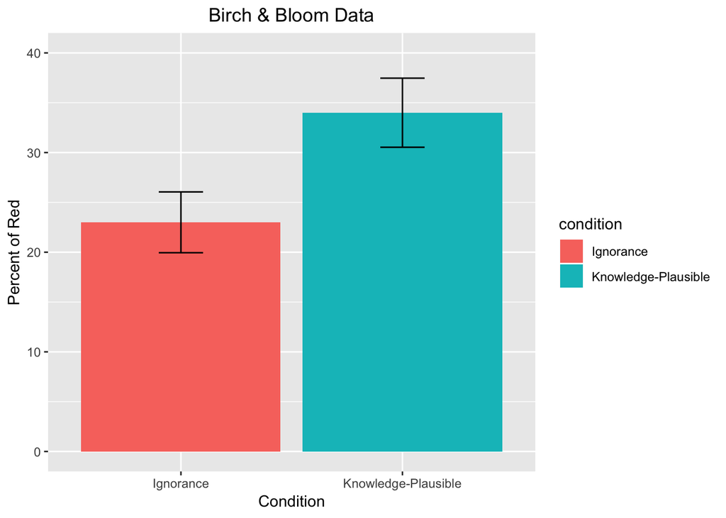

```r
birch_bloom_data= data.frame(
  condition=c("Ignorance","Ignorance","Ignorance","Ignorance",
         "Knowledge-Plausible","Knowledge-Plausible","Knowledge-Plausible","Knowledge-Plausible"
         ),

  container=c("blue",
              "red",
              "purple",
              "green"
              ),
  probability_percent =c(71, 23, 2, 3, #ignorance mean
                59, 34, 3, 4 #knowledge-plausible mean
                ),
  standard_deviation = c(26, 22, 5, 7, #ignorance_standarddeviation
                        27, 25, 5, 7), #knowledge-plausible_standarddeviation
  n = c(52, 52, 52, 52,
        52, 52, 52, 52)
                 ) %>%
  mutate(standard_error = standard_deviation / sqrt(n))

filtered_birch_bloom_data = birch_bloom_data %>%
  filter(container=="red")

# Birch and Bloom bar graph
ggplot(filtered_birch_bloom_data, aes(x=condition, y=probability_percent, fill=condition)) +
  geom_bar(position="dodge", stat="identity") +
ggtitle("Birch & Bloom Data") +
theme(plot.title=element_text(hjust=.5)) +
geom_errorbar(aes(ymin=probability_percent - standard_error, ymax = probability_percent + standard_error), width=.2) +
ylim(min(0), max(40)) +
xlab("Condition") +
ylab("Percent of Red")
```

[output not shown]

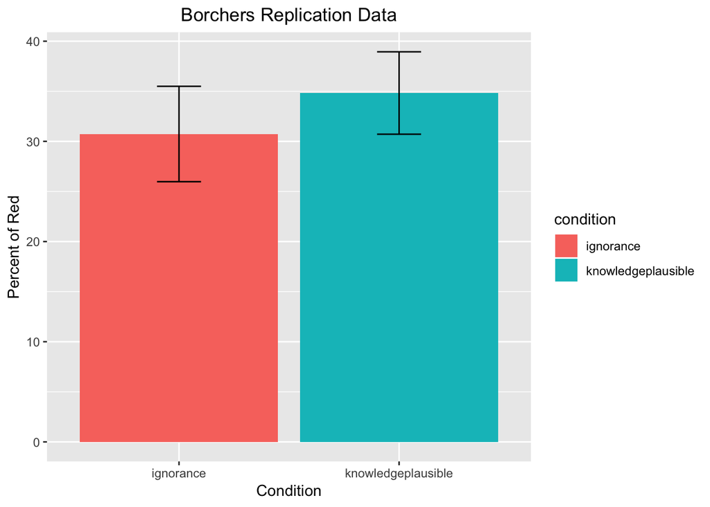

```r
borchers_replication_filtered_data %>%
  filter(color=="red") %>%
  ggplot() +
  aes(x=condition, y=probability_pct, fill=condition) +
  stat_summary(geom="bar") +
  stat_summary(geom="errorbar", width =0.2, fun.data=mean_se) +
  xlab("Condition") +
  ylab("Percent of Red") +
  ggtitle("Borchers Replication Data") +
  scale_color_hue(labels= c("Ignorance", "Knowledge-plausible")) +
  theme(plot.title=element_text(hjust=.5))
```

### Exploratory analyses

```r
t.test(blue ~ condition, data=borchers_replication_final_data)
```

```
##
##  Welch Two Sample t-test
##
## data:  blue by condition
## t = 0.87243, df = 70.613, p-value = 0.3859
## alternative hypothesis: true difference in means is not equal to 0
## 95 percent confidence interval:
##  -8.795081 22.476284
## sample estimates:
##          mean in group ignorance mean in group knowledgeplausible
##                         56.52632                         49.68571
```

```r
t.test(purple ~ condition, data=borchers_replication_final_data)
```

```
##
##  Welch Two Sample t-test
##
## data:  purple by condition
## t = 0.18851, df = 70.628, p-value = 0.851
## alternative hypothesis: true difference in means is not equal to 0
## 95 percent confidence interval:
##  -7.972317  9.636979
## sample estimates:
##          mean in group ignorance mean in group knowledgeplausible
##                         12.28947                         11.45714
```

```r
t.test(green ~ condition, data=borchers_replication_final_data)
```

```
##
##  Welch Two Sample t-test
##
## data:  green by condition
## t = -0.219, df = 67.037, p-value = 0.8273
## alternative hypothesis: true difference in means is not equal to 0
## 95 percent confidence interval:
##  -8.121699  6.515684
## sample estimates:
##          mean in group ignorance mean in group knowledgeplausible
##                         9.368421                        10.171429
```

```r
# Calculating Standard Deviation ignorance condition containers
condition_ignorance = borchers_replication_final_data %>%
  filter(condition=="ignorance")

sd(condition_ignorance$blue)
```

```
## [1] 36.1085
```

```r
sd(condition_ignorance$red)
```

```
## [1] 29.34758
```

```r
sd(condition_ignorance$purple)
```

```
## [1] 18.95216
```

```r
sd(condition_ignorance$green)
```

```
## [1] 14.28933
```

```r
# Calculating Standard Deviation knowledge-plausible condition containers
condition_knowledge_plausible = borchers_replication_final_data %>%
  filter(condition=="knowledgeplausible")

sd(condition_knowledge_plausible$blue)
```

```
## [1] 30.83616
```

```r
sd(condition_knowledge_plausible$red)
```

```
## [1] 24.32922
```

```r
sd(condition_knowledge_plausible$purple)
```

```
## [1] 18.74809
```

```r
sd(condition_knowledge_plausible$green)
```

```
## [1] 16.80771
```

```r
# Attention check. Excluding participants who reported a total probability percent greater than 100%
borchers_replication_final_data <- transform(borchers_replication_final_data,
total_probability_percent = blue + red + purple + green)

borchers_replication_100 = borchers_replication_final_data %>%
  filter(total_probability_percent==100)

# Conducting t-tests excluding participants who reported more than 100% probability for all containers
# Pattern of results does not change
t.test(blue ~ condition, data=borchers_replication_100)
```

```
##
##  Welch Two Sample t-test
##
## data:  blue by condition
## t = 0.99932, df = 65.2, p-value = 0.3213
## alternative hypothesis: true difference in means is not equal to 0
## 95 percent confidence interval:
##  -8.19021 24.59714
## sample estimates:
##          mean in group ignorance mean in group knowledgeplausible
##                         56.14286                         47.93939
```

```r
t.test(red ~ condition, data=borchers_replication_100)
```

```
##
##  Welch Two Sample t-test
##
## data:  red by condition
## t = -1.0853, df = 65.741, p-value = 0.2818
## alternative hypothesis: true difference in means is not equal to 0
## 95 percent confidence interval:
##  -18.808998   5.562245
## sample estimates:
##          mean in group ignorance mean in group knowledgeplausible
##                         27.28571                         33.90909
```

```r
t.test(purple ~ condition, data=borchers_replication_100)
```

```
##
##  Welch Two Sample t-test
##
## data:  purple by condition
## t = -0.30109, df = 62.306, p-value = 0.7643
## alternative hypothesis: true difference in means is not equal to 0
## 95 percent confidence interval:
##  -7.764088  5.731187
## sample estimates:
##          mean in group ignorance mean in group knowledgeplausible
##                         8.771429                         9.787879
```

```r
t.test(green ~ condition, data=borchers_replication_100)
```

```
##
##  Welch Two Sample t-test
##
## data:  green by condition
## t = -0.19102, df = 59.946, p-value = 0.8492
## alternative hypothesis: true difference in means is not equal to 0
## 95 percent confidence interval:
##  -6.465814  5.338541
## sample estimates:
##          mean in group ignorance mean in group knowledgeplausible
##                         7.800000                         8.363636
```

```r
# Attention check - Calculating Standard Deviation ignorance condition containers
condition_ignorance_attention_check = borchers_replication_100 %>%
  filter(condition=="ignorance")

sd(condition_ignorance_attention_check$blue)
```

```
## [1] 36.68238
```

```r
sd(condition_ignorance_attention_check$red)
```

```
## [1] 26.69057
```

```r
sd(condition_ignorance_attention_check$purple)
```

```
## [1] 12.52782
```

```r
sd(condition_ignorance_attention_check$green)
```

```
## [1] 10.42
```

```r
# Attention check - Calculating Standard Deviation knowledge-plausible condition containers
condition_knowledge_plausible_attention_check = borchers_replication_100 %>%
  filter(condition=="knowledgeplausible")

sd(condition_knowledge_plausible_attention_check$blue)
```

```
## [1] 30.90504
```

```r
sd(condition_knowledge_plausible_attention_check$red)
```

```
## [1] 23.60927
```

```r
sd(condition_knowledge_plausible_attention_check$purple)
```

```
## [1] 15.10331
```

```r
sd(condition_knowledge_plausible_attention_check$green)
```

```
## [1] 13.59875
```

## Discussion

### Summary of Replication Attempt

My replication attempt of the Curse of Knowledge in Reasoning About False Beliefs originally conducted by Susan Birch and Paul Bloom failed to replicate (Birch & Bloom, 2007). The main finding reported by the authors was that participants in the ignorance condition reported lower probabilities that Vicki would first look in the red container compared to participants in the knowledge-plausible condition. In my replication, there was no statistically significant difference between the ignorance (M = 30.74, SD = 29.35) and the knowledge-plausible (M = 34.83, SD = 24.33) conditions in their reported probability regarding the red container, t = -0.65, df = 70.25, p = .518. Regarding the knowledge-plausible condition, I found nearly the same average probability that Vicki would first look in the red container (34%) as Birch & Bloom (34%). However, in my sample, the ignorance condition reported higher probabilities that Vicki would first look in the red container (30%) compared to the original article (23%), therefore explaining the non-significant findings.

### Commentary

The original authors also reported that participants in the ignorance condition reported higher probabilities that Vicki would first look in the blue container compared to participants in the knowledge-plausible condition. Exploratory analyses revealed that the authors’ secondary finding that participants in the ignorance condition reported higher probabilities for the blue container also failed to replicate (ignorance: M = 56.53, SD = 36.11; knowledge-plausible M = 49.69, SD = 30.84; t = 0.87, df = 70.61, p = .386). As previously stated, I did not include the knowledge-implausible condition because the authors reported that there were no statistically significant differences between this condition compared to the ignorance condition. I conducted additional t-tests comparing the ignorance condition to the knowledge-plausible condition for the purple (p = .851) and green containers (p = .827). Similar to Birch & Bloom, I did not observe statistically significant differences between the conditions’ reported probabilities. It is important to note, however, that one cannot confirm a null finding. I noticed that participants in my sample reported higher probabilities for the purple (ignorance: 12%; knowledge-plausible: 12%) and green (ignorance: 9%; knowledge-plausible: 10%) containers compared to Birch & Bloom (purple - ignorance: 2%; knowledge-plausible: 3%; green - ignorance: 3%; knowledge-plausible: 4%). I conducted an attention check excluding participants who reported probabilities greater than 100%. The pattern of results persisted.

There are notable differences across the two samples that should be addressed. First, the original authors’ sample consisted of 45% men, whereas my sample consisted of 63% men. While I don’t speculate that gender would impact reported probabilities, the difference in the proportion of men could be an important factor. Further, my sample was approximately 33 years old, while the original participants were students enrolled in an introductory psychology course at Yale University. Therefore, there were likely significant differences in the age of the two samples. Third, while I excluded participants who did not attend high school, there is a potential difference in educational attainment. Finally, it’s important to highlight the fact that my survey was conducted online via MTurk and not in person. It is possible that this medium may have impacted results. While I think it is important to speculate potential confounding variables across studies, I do not think any of these differences led to the non-significant findings. If an effect is truly robust, it should be able to withstand small differences in biological sex, age, educational attainment, and how the survey was distributed. The first author did not respond to my query asking for feedback on my paradigm, however the original figure was provided in their article. Therefore, I conclude that my survey had high fidelity to the original survey in its design.